# CrispriVoucherHZI

Ls,Em

4/8/2021

### Data Sets

- CUI (in code referred as rousset):
  - *A CRISPRi screen in E. coli reveals sequence-specific toxicity of dCas9* from Cui, 2018 and data is Suppl Table 5
  - Two different expression systems: E18 (higher dCAS expression) & E75 (lower dCAS expression)
  - Strain LC-E75 carrying this fine-tuned Ptet-dCas9 cassette was then used to perform a genome-wide dCas9 knockdown screen following the same protocol as the screen previously performed with strain LC-E18. As expected, many guides that produced a strong fitness defect in strain LC-E18 had a weaker or no effect in strain LC-E75, but targets in the coding strand of essential genes still produced a strong fitness defect
  - *paper*: https://www.nature.com/articles/s41467-018-04209-5#Sec26
- wang:
  - E. coli MCm carrying the pdCas9-J23111 or pKanaNC (negative control) plasmid
  - only 1 data set
  - *paper:* https://www.nature.com/articles/s41467-018-04899-x

### Existing Filtering Approaches

- Pasteur Model:
  - Coding strand == 1
  - Number guides per gene > 4
  - Median log2FC per gene < -2
- HZI (Lars&Yan):
  - gRNAs targeting essential genes (“gene_essentiality” == 1)
  - Coding strand (“coding_strand” feature == 1)
  - Not in intergenic region (“intergenic” ==0)
  - After filter:
    - wang: 4197 guides
    - rousset (E18 & E75): 1951 guides

### Our Filtering Approach

- filtering:
  - gRNAs targeting essential genes (“gene_essentiality” == 1)
  - Coding strand (“coding_strand” feature == 1)
  - Not in intergenic region (“intergenic” ==0)
  - number guides per gene > 4
  - median log2FC per gene < -2
  - After filter:
    - wang: 3391 guides
    - rousset (E18 & E75): 1387 and 1313 guides

### Feature Preprocessing

- removed features:
  - gene id (only use for group k-fold)
  - distance_operon_pers (highly correlates with distance_operon)
  - distance_start_codon_perc (highly correlates with distance_start_codon)
- log2 transform gene expression measures
- standardize all features but sequence features (Does not apply to tree-based models)

### Genome-wide essentiallity screens

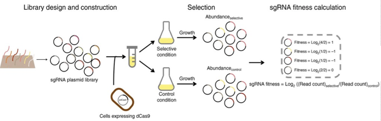

Data Set.

**Experimental setup for genome wide essentiality screens.**

**Steps:**

**Problem:**

- log2FC is only proxy of guide efficiency because it contains confounding gene effects

**Approaches for Separation of Gene and Guide Effects:**

- Batch effect and confounding factor correction methods do not work because we only have one condition not multiple conditions (e.g. control and disease)
- Median subtraction: Removes gene effect from target by taking the median log2FC over all guides per gene and then subtracting the median from each guide log2FC of that gene
  - source: pasteur model (https://academic.oup.com/nar/article/48/11/e64/5827197)
  - pros: quantitative measure
  - cons: we cannot be sure that the median is a good representation of the gene effect
- Normalized ranks: Removes gene effect from target by ranking all guides of each gene by their log2FC and then calculating a normalized rank by dividing the rank by the number of guides per gene
  - source: Doench 2014 (https://www.nature.com/articles/nbt.3026) and Doench 2016 (https://www.ncbi.nlm.nih.gov/pmc/articles/PMC4744125/#SD2)
  - pros: Ranking value is without any gene effect
  - cons: measure is not quantitative -> it does not show when guides have very similar log2FCs
- Predicted median log2FC: median log2FC predicted from only gene features
  - did not lead good model performances
- Predicted log2FC: log2FC predicted from only gene features
  - did not lead good model performances

## Models

### Existing Shallow Models

- Pasteur model:
  - methods: L1-regularized (Lasso) linear regression
  - dataset: rousset E75
  - performance measure: pearson and spearman
  - *paper*: https://academic.oup.com/nar/article/48/11/e64/5827197
  - *git repo*: https://gitlab.pasteur.fr/dbikard/ecowg1
- Doench model:
- methods:
  - linear regression
  - L1-regularized (Lasso) linear regression
  - L2-regularized (Ridge) linear regression
  - the hybrid SVM plus logistic regression approach
  - Random Forest
  - Gradient-boosted regression tree
  - L1 logistic regression (a classifier)
  - SVM Classification
- dataset: A375, HT29, 293T, MOLM13, BV2 cell lines
- performance measure: FDR
- *paper*:
- Doench 2014: https://www.nature.com/articles/nbt.3026
- Doench 2016: https://www.ncbi.nlm.nih.gov/pmc/articles/PMC4744125/#SD2
- Fusi et al.:
  - Lasso model
  - https://www.biorxiv.org/content/10.1101/021568v1.full.pdf

### Our Shallow Models

**Baseline Models**

- linear regression
- lasso/elnet

**Advanced Models**

- Random Forest
- Random forest + Recursive Feature Elimination
  - do not use Gini index because it is biased towards variables with many possible split points (not good if binary, e.g. dummy variables, are included)
  - Better to use mean decrease in accuracy (MDA)
  - problem: RFE with MDA takes too long -> use gini index although not optimal
- Mixed Effect RF:
  - fixed effects (guide) and random effects (gene) are learned separately
  - unseen genes only use fixed effects
  - https://towardsdatascience.com/mixed-effects-random-forests-6ecbb85cb177
- GBM

### Deep Models

- Sequence layers: one-hot encoding of nucleotide vs sequence position
  - 1D CNN: filters slide over sequence position
  - GRU: sequence positions are hidden states
    - GRU has less parameters
- Sequence and tabular features are processed separately and concatenated in the last layer

### Existing Appication of Deep Learning Models on Crispr

- LSTM: https://www.nature.com/articles/s41467-019-12281-8
- CNN: https://www.nature.com/articles/nbt.4061#Sec21

## Training

###How to Combine Different Data Sets

- Train on one or both rousset + part of wang and then test on the rest of wang
- Use group k-fold CV to make sure we that we test on guides of unseen genes

Problems:

- Including both rousset data sets might not be good since both come from different expression systems
- Combining wang and one of the rousset data sets? -> test on second Rousset
  - *does not work* because both roussets are too similar –> it’s like training on test set

## Challenges:

- number of samples are low: ~2k and ~4k for different datasets
- number of features can be quite high when sequence features are encoded

## Requirements:

- final model needs to work with only guide features on unseen genes!
- final model needs to generalize well to blind-test data: collaborators created separate data set with several hundred guides (for 9 genes)

## Features

- gene features (not used in final model)
  - tabular data
- guide features
  - tabular data
  - sequence features: PAM, 20 nt spacer, 30 or 40 nt surrounding region
- processing:
  - tabular data: original (for tree-based methods) or standardized values
  - sequence features for ML models (PAM, 20nt spacer and 40nt surrounding region):
    - one-hot encoding of nucleotides and dinucleotides
  - sequence features for DL models:
    - one-hot encoding (matrix: sequence x alphabet) of 40 nt region around spacer+PAM

## crossvalidation

- ~ 10 guides / gene but each guide only targets one gene
- tune hyperparameters: use 5 fold group k-fold cross validation (inner folds)
  - for each 5 folds, 5 different models are trained with different training and validation datasets
  - final prediction: average of those 5 models
- access model stability: use 5 fold group k-fold cross validation (outer folds)

## training combinations

For the final models: - target: median sub; features: guide features - target: normalized rank; features: guide features (performed worse than median-sub model)

## evaluation

- Aim is to create a tool to guide researches to evaluate and design better guides for CRISPRi experiments
  - Problem: We dont have a ground truth since there is no experiment to measure only guide efficiency (without gene effect)
- Possible evaluation metrics
  - Spearman correlation and MSE is calculated against processed target (median subtracted) -Spearman -If all guides for a given gene have very similar efficiency, small differences in our models’ predictions can have a large impact on spearman correlation coefficient although model can still pick top guides.

**High Correlation**

[figure not shown]

- Gene b0184: Spearman = 0.81 (elnet)

[figure not shown]

- Gene b0098: Spearman = 0.82 (elnet)

[figure not shown]

- Gene b3783: Spearman = 0.84 (elnet)

**Low Correlation**

[figure not shown]

[figure not shown]

[figure not shown]

-MSE - Need to scale results in order to compare models and also deal with outliers

Our Evaluation

Choose top N guides per gene based on predictions from each model. After we retrieve actual guide efficiency values of top N guides. We compare mean of top N guides we picked to mean of remaining guides for each gene. We use wilcoxon rank statistical test to asses if there is a meaningful positive difference between guide efficiency of each group (Top N vs remaining guides).

This evaluation scheme fits actual use case where researcher can quickly generate as many guides as possible computationally and then use the tool to pick N guides and experiment with them only. Even if we choose N quite low such as top 1 or Top 3 in Cui, Wang and Purine test cases our models can pick guides with high efficiency.

How to compare models?

- https://pubmed.ncbi.nlm.nih.gov/33504883/
- https://github.com/wiesenfa/challengeR

We used ChallengeR package to pick the best model to test on Purine external test set which consists of 9 genes with 750 guides.

ChallengeR package is created to evaluate algorithms on different tasks and datasets using a metric value defined by user (e.g. challenge organizer).

-For ChallengeR,

-Tasks(Dataset): - Wang - Cui18 - Cui75 - Wang + Cui18 - Wang + Cui75

-Algorithms(Models): - Elnet - GBM - Random Forest - 1D CNN

Each gene constitute of multiple guides is a single task in ChallengR. We only selected genes with more than 10 guides.

TestCases: - Wang 228 genes (TestCases) - Cui18 46 genes (TestCases) - Cui75 45 genes (TestCases) - Wang + Cui18 228 genes (TestCases) since we used only Wang dataset for test - Wang + Cui75 228 genes (TestCases) since we used only Wang dataset for test

MetricValue:

We used the mean of actual log2FC of Top N guides which are selected by each algorithm based on predicted Log2FC values using only guide features.

One of the representation, that is provided by the ChallengeR report is a stacked frequency plot of the observed ranks, separated by algorithm. Observed ranks across bootstrap samples(1000) are displayed with coloring according to the task. For algorithms that achieve the same rank in different tasks for the full assessment data set, vertical lines are on top of each other. Vertical lines allow to compare the achieved rank of each algorithm over different tasks.

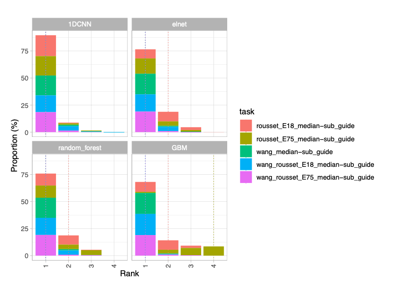

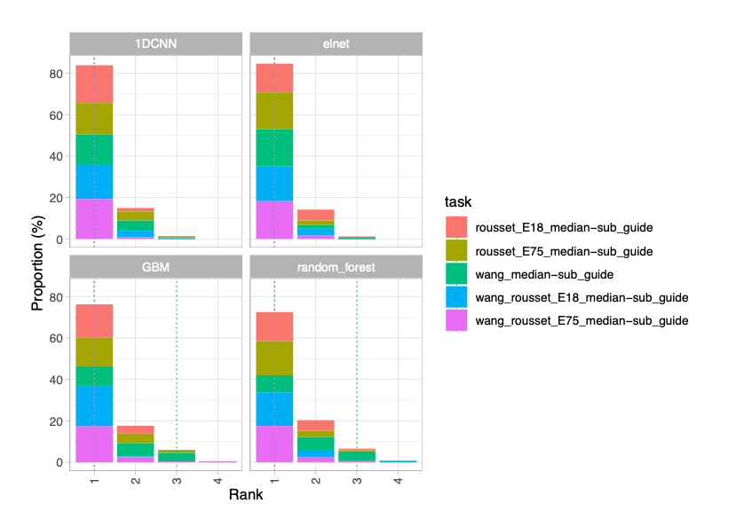

Comparison of different model looks almost random. We can not clearly pick the best model since majority of the cases all models share rank 1. However, 1DCNN and Elnet slightly outperform other models. We decided to keep 1D CNN (highest complexity) and Elnet models(lowest complexity) for further evaluation on external test set of Purine genes.

## Evaluation on Purine Dataset (External Dataset)

Here we evaluated 1D CNN and Elnet trained on Wang+Cui18 and Wang+Cui75 datasets. We tested them on 9 different Purine genes with total of 750 guides. For each gene we show top 1 and top 3 guides selected by each algorithm with Log2FC histogram of all guides.

**Purine A**

[figure not shown]

**Purine C**

[figure not shown]

**Purine D**

[figure not shown]

**Purine E**

[figure not shown]

**Purine F**

[figure not shown]

**Purine H**

[figure not shown]

**Purine K**

[figure not shown]

**Purine L**

[figure not shown]

**Purine M**

[figure not shown]